# Прогнозирование оттока клиентов

### Двумерные графики

Изучим двухмерные графики по количественным признакам в паре с целевым `'broken_contract'`.

График распределения и диаграмма размаха значений признака "begin_date" с разделением по признаку "broken_contract"

|  | count | mean | min | 25% | 50% | 75% | max |
| --- | --- | --- | --- | --- | --- | --- | --- |
| No | 5938 | 2017-08-21 11:10:02.627147008 | 2013-10-01 | 2015-12-01 | 2018-03-01 | 2019-06-01 | 2020-02-01 |
| Yes | 1101 | 2015-08-30 21:37:26.321526016 | 2013-12-01 | 2014-06-01 | 2015-05-01 | 2016-08-01 | 2019-10-01 |

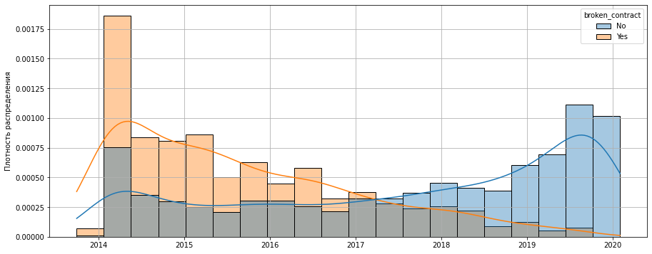

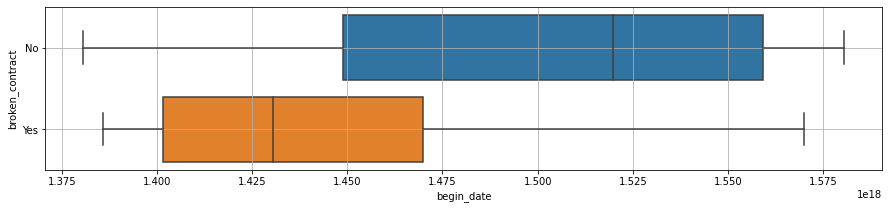

График распределения и диаграмма размаха значений признака "contract_duration" с разделением по признаку "broken_contract"

|  | count | mean | std | min | 25% | 50% | 75% | max |
| --- | --- | --- | --- | --- | --- | --- | --- | --- |
| No | 5938.0 | 893.534692 | 716.629748 | 0.0 | 245.0 | 702.0 | 1523.0 | 2314.0 |
| Yes | 1101.0 | 924.863760 | 458.771309 | 28.0 | 577.0 | 915.0 | 1249.0 | 2129.0 |

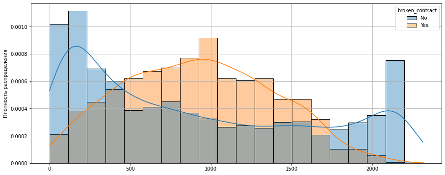

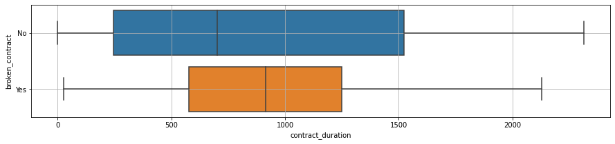

График распределения и диаграмма размаха значений признака "monthly_charges" с разделением по признаку "broken_contract"

|  | count | mean | std | min | 25% | 50% | 75% | max |
| --- | --- | --- | --- | --- | --- | --- | --- | --- |
| No | 5938.0 | 62.775514 | 29.832827 | 18.25 | 30.10 | 69.225 | 87.2375 | 118.60 |
| Yes | 1101.0 | 75.546004 | 29.116213 | 18.40 | 56.15 | 84.200 | 99.5000 | 118.75 |

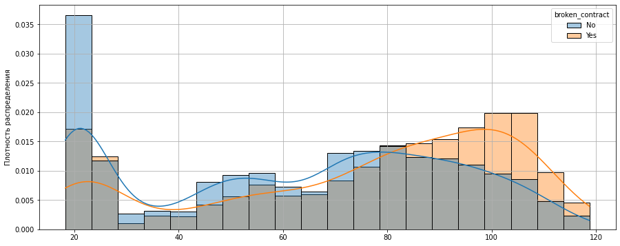

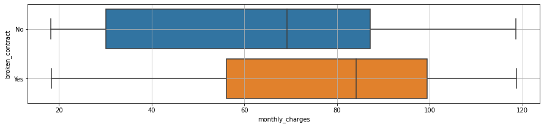

График распределения и диаграмма размаха значений признака "total_charges" с разделением по признаку "broken_contract"

|  | count | mean | std | min | 25% | 50% | 75% | max |
| --- | --- | --- | --- | --- | --- | --- | --- | --- |
| No | 5938.0 | 2067.561783 | 2192.864168 | 0.00 | 374.6475 | 1192.80 | 3173.8375 | 9221.38 |
| Yes | 1101.0 | 2371.377275 | 1581.862275 | 77.84 | 1048.0500 | 2139.03 | 3404.9100 | 7649.76 |

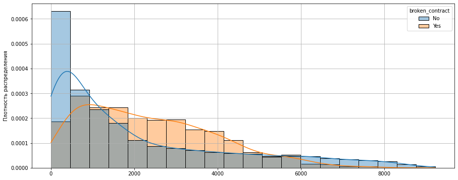

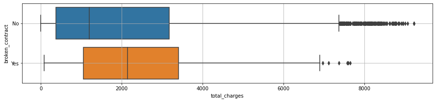

График распределения и диаграмма размаха значений признака "additional_services" с разделением по признаку "broken_contract"

|  | count | mean | std | min | 25% | 50% | 75% | max |
| --- | --- | --- | --- | --- | --- | --- | --- | --- |
| No | 5938.0 | 2.277703 | 2.010461 | 0.0 | 0.0 | 2.0 | 4.0 | 7.0 |
| Yes | 1101.0 | 3.443233 | 1.947423 | 0.0 | 2.0 | 4.0 | 5.0 | 7.0 |

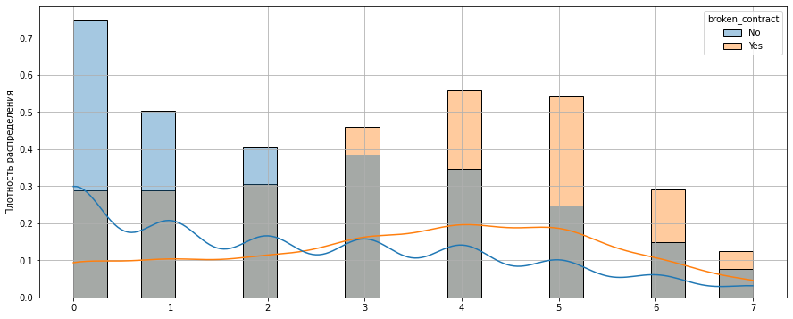

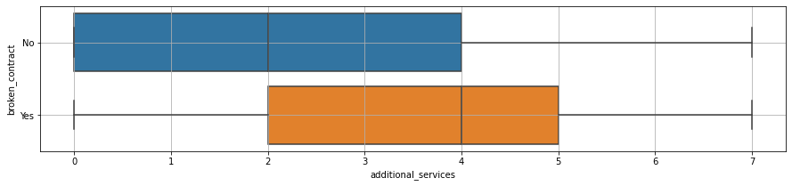

```python
for num_column in num_col(full_data).drop('end_date'):

    num_hue_plot(full_data, num_column, 'broken_contract')
```

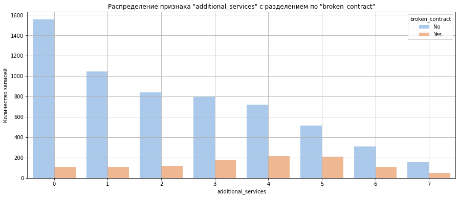

```python
plt.figure(figsize=(15, 6))
sns.countplot(data=full_data, x='additional_services', hue='broken_contract', palette='pastel')
plt.grid(True)
plt.xlabel('additional_services')
plt.ylabel('Количество записей')
plt.title('Распределение признака "additional_services" с разделением по "broken_contract"')
plt.show()
```

Мы видим следующее:

- Дата подписания договора у ушедших клиентов равномерно уменьшается с каждым годом к нашему времени. Наибольшее количество ушедших клиентов подписывали договор в 2014 году.
- Распределение длительности контракта у ушедших клиентов отличается, оно похоже на нормальное с очень широким распределением. Чаще всего уходят клиенты, которые пользуются услугами от 1.5 до 3.5 лет. Клиенты с длительностью контракта менее года и более 4.5 лет уходят гораздо реже.
- По размеру ежемесячной оплаты видно, что клиенты из первой группы (оплачивающих не более 30 у.е.) уходят гораздо реже. Распределение ушедших клиентов очень широкое - пик, хоть и небольшой, приходится на тех, кто оплачивает 100—105 у.е. в месяц. Среди тех, кто платит более 100 у.е. в месяц на ушедших приходится около трети клиентов, что очень много.
- Общие расходы среди ушедших клиентов сравнительно выше тех, кто остался.
- Ушедших клиентов больше среди подключивших большее количество дополнительных услуг.